## Section 6: Convert your Matplotlib plots to Plotly

Welcome to Plotly's Python API User Guide.

> Links to the other sections are on the User Guide's homepage  
> The Github repository is available [here](https://github.com/plotly/python-user-guide)

Section 6 is divided as follows:

- 6.1 Matplotlib to Plotly conversion basics
- 6.2 Supported plot types
- 6.3 Converting subplots
- 6.4 The nitty gritty of matplotlylib

Quickstart (make Plotly plot from matplotlib figure object):

```
>>> import plotly.plotly as py
>>> import matplotlib.pyplot as plt
>>> # auto sign-in with credentials or use py.sign_in()
>>> mpl_fig_obj= plt.figure()
>>> # ... make a matplotlib figure ...
>>> py.plot_mpl(mpl_fig_obj)
```

The User Guide assumes version 1.0 and up of Plotly's Python API.

Check which version is installed on your machine and please upgrade if needed.

```python
# (*) Import plotly package
import plotly

# Check plolty version (if not latest, please upgrade)
plotly.__version__
```

```
'1.6.6'
```

See the User Guide's homepage for more info on installation and upgrading.

##### Matplotlib + Plotly = Matplotlylib

The matplotlylib project is a collaboration between [Plotly](https://plot.ly/) , [mpld3](http://mpld3.github.io/) and [Jake Vanderplas](https://github.com/jakevdp) that lets you convert matplotlib figures to beautiful [D3.js](http://d3js.org/) graphs with Plotly's Python API.

The goal of mpld3 is to expand Python's matplotlib plotting package use to the browser. Now, together with Plotly, users can share their plots and data sets online, for free.

While Plotly's Python API gives users access to Plotly directly, users may already have high-quality plots that they want to get online and share. Standing on the shoulders of the mplexporter , matplotlylib allows users to convert matplotlib figures to Plotly figures with a simple function call.

If your data sets are important to you, they are important to us, and we will help you share them with others. As a bonus, you will be able to use Plotly's awesome interactive web GUI.

This section showcases the current state of matplotlylib and how you can incorporate it into your workflow.

We first import a few modules and sign in to Plotly using our credentials file

```python
# (*) To communicate with Plotly's server, sign in with credentials file
import plotly.plotly as py

# (*) Useful Python/Plotly tools
import plotly.tools as tls

# (*) Graph objects to piece together plots
from plotly.graph_objs import *

import numpy as np  # (*) numpy for math functions and arrays
```

If you are not familiar with credentials files, refer to the User Guide's homepage .

We also need to import matplotlib and let's turn on the IPython inline magic to display matplotlib plots directly inside this notebook.

```python
import matplotlib.pyplot as plt # (*) import matplotlib

%matplotlib inline
```

### 6.1 Matplotlib to Plotly conversion basics

To convert a matplotlib figure to a Plotly figure, Python API users now have, in version 1.0, the following three functions made available to them:

- `tls.mpl_to_plotly` : takes in a matplotlib figure object (i.e. `mpl_fig = plt.figure()` ) and returns a Plotly figure object
- `py.plot_mpl` : takes in a matplotlib figure object and creates a Plotly plot at a unique URL, and optionally opens a new browser tab at this URL.
- `py.iplot_mpl` : similar to `py.plot_mpl` but for IPython notebook use. It displays the returned Plotly figure directly in the IPython notebook in session.

So, let's get started by generating this [damped oscillation graph](http://matplotlib.org/examples/pylab_examples/legend_demo2.html) using matplotlib. The following code cell has been adapted from the matplotlib example bank. Thanks!

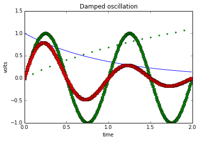

```python
# Package all mpl plotting commands inside one function
def plot_mpl_fig():

    # Make two time arrays
    t1 = np.arange(0.0, 2.0, 0.1)
    t2 = np.arange(0.0, 2.0, 0.01)

    # N.B. .plot() returns a list of lines.
    # The "l1, = plot" usage extracts the first element of the list
    # into l1 using tuple unpacking.
    # So, l1 is a Line2D instance, not a sequence of lines
    l1, = plt.plot(t2, np.exp(-t2), label='decaying exp.')
    l2, l3 = plt.plot(t2, np.sin(2 * np.pi * t2), '--go',
                      t1, np.log(1 + t1), '.')
    l4, = plt.plot(t2, np.exp(-t2) * np.sin(2 * np.pi * t2), 'rs-.')

    # Add axis labels and title
    plt.xlabel('time')
    plt.ylabel('volts')
    plt.title('Damped oscillation')

    return (l1, l2, l3, l4)  # return line objects (for legend, later)

# Plot it!
plot_mpl_fig()

# N.B. get matplotlib figure object and assign a variable to it
mpl_fig1 = plt.gcf()
```

Note that in the above we retrieved the matplotlib figure object after generating the plot, using

```
plt.gcf()
```

where `.gcf()` stands for get current figure. Equivalently, we can use

```
plt.figure()
```

to initialize the figure object before the plotting commands. The latter method is used in this section from this point on.

##### Convert a matplotlib figure object to a Plotly figure object

Let's first try out the `tls.mpl_to_plotly` function.

As always, a good way to start is to run help on the object in question:

```python
help(tls.mpl_to_plotly)
```

```
Help on function mpl_to_plotly in module plotly.tools:

mpl_to_plotly(fig, resize=False, strip_style=False, verbose=False)
    Convert a matplotlib figure to plotly dictionary and send.

    All available information about matplotlib visualizations are stored
    within a matplotlib.figure.Figure object. You can create a plot in python
    using matplotlib, store the figure object, and then pass this object to
    the fig_to_plotly function. In the background, mplexporter is used to
    crawl through the mpl figure object for appropriate information. This
    information is then systematically sent to the PlotlyRenderer which
    creates the JSON structure used to make plotly visualizations. Finally,
    these dictionaries are sent to plotly and your browser should open up a
    new tab for viewing! Optionally, if you're working in IPython, you can
    set notebook=True and the PlotlyRenderer will call plotly.iplot instead
    of plotly.plot to have the graph appear directly in the IPython notebook.

    Note, this function gives the user access to a simple, one-line way to
    render an mpl figure in plotly. If you need to trouble shoot, you can do
    this step manually by NOT running this fuction and entereing the following:

    ===========================================================================
    from mplexporter import Exporter
    from mplexporter.renderers import PlotlyRenderer

    # create an mpl figure and store it under a varialble 'fig'

    renderer = PlotlyRenderer()
    exporter = Exporter(renderer)
    exporter.run(fig)
    ===========================================================================

    You can then inspect the JSON structures by accessing these:

    renderer.layout -- a plotly layout dictionary
    renderer.data -- a list of plotly data dictionaries

    Positional arguments:
    fig -- a matplotlib figure object
    username -- a valid plotly username **
    api_key -- a valid api_key for the above username **
    notebook -- an option for use with an IPython notebook

    ** Don't have a username/api_key? Try looking here:
    https://plot.ly/plot

    ** Forgot your api_key? Try signing in and looking here:
    https://plot.ly/python/getting-started
```

So, we convert the matplotlib figure object of our previous figure to a Plotly figure object, with verbose turned on just for fun:

```python
py_fig1 = tls.mpl_to_plotly(mpl_fig1, verbose=True)
```

```
Initialized PlotlyRenderer
Opening figure
  Opening axes
    Attempting to draw a line ... with just lines
    Heck yeah, I drew that line
    Attempting to draw a line ... with both lines+markers
    Heck yeah, I drew that line
    Attempting to draw a line ... with just markers
    Heck yeah, I drew that line
    Attempting to draw a line ... with both lines+markers
    Heck yeah, I drew that line
    Attempting to draw an mpl text object
      Text object is an xlabel
        Adding xlabel
    Attempting to draw an mpl text object
      Text object is a ylabel
        Adding ylabel
    Attempting to draw an mpl text object
      Text object is a title
        Attempting to draw a title
          Only one subplot found, adding as a plotly title
  Closing axes
Closing figure
```

Now, print the yielded Plotly figure object:

```python
print(py_fig1.to_string())
```

```
Figure(
    data=Data([
        Scatter(
            x=[0.0, 0.01, 0.02, 0.029999999999999999, 0.040000000000000001,  ],
            y=[1.0, 0.99004983374916811, 0.98019867330675525, 0.970445533.., ],
            mode='lines',
            name='decaying exp.',
            line=Line(
                color='#0000FF',
                width=1.0,
                dash='solid',
                opacity=1
            ),
            xaxis='x1',
            yaxis='y1'
        ),
        Scatter(
            x=[0.0, 0.01, 0.02, 0.029999999999999999, 0.040000000000000001,  ],
            y=[0.0, 0.062790519529313374, 0.12533323356430426, 0.18738131.., ],
            mode='lines+markers',
            name='_line1',
            marker=Marker(
                color='#007F00',
                size=6,
                symbol='dot',
                line=Line(
                    color='#000000',
                    width=0.5
                ),
                opacity=1
            ),
            line=Line(
                color='#007F00',
                width=1.0,
                dash='dash',
                opacity=1
            ),
            xaxis='x1',
            yaxis='y1'
        ),
```

[output cut: 90 more lines]

```
            type='linear',
            showgrid=False,
            zeroline=False,
            showline=True,
            nticks=6,
            ticks='inside',
            tickfont=Font(
                size=10.0
            ),
            mirror='ticks',
            anchor='x1',
            side='left'
        )
    )
)
```

And there it is. A full Plotly figure object corresponding to our matplotlib plot!

Even though the matplotlib plot only has one x-axis and one y-axis, matplotlylib converted the matplotlib axes to `'xaxis1'` and `'yaxis1'` keys in the Plotly layout object, consistent with figure object containing subplots (more in subsection 6.3 ).

Moreover, note that `tls.mpl_to_plotly` comes with a few optional keyword arguments. Namely, `resize` and `strip_style` which give users some flexibiliy in the conversion.

By default, the converted Plotly figure object keeps the original matplotlib figure's size in pixels. These specifications are linked to the `'layout'` key of the Plotly figure object. More specifically for our first figure:

```python
# Print key-value pairs corresponding to the figure's size
for i in ['autosize', 'width', 'height']:
    print i, py_fig1['layout'][i]
```

```
autosize False
width 480
height 320
```

Then, setting `resize` to `True` in the `tls.mpl_to_plotly` call effectively deletes the three above keys (as the `.pop()` dictionary method would do). In this case, the converted Plotly figure object acquires Plotly's auto-size functionality when plotted.

The `strip_style` argument allows users to convert a matplotlib figure to Plotly's beautiful default style settting without having to manipulation the Plotly figure object. The `strip_style` argument is in display next.

##### Plot a matplotlib figure in Plotly

Start by running help on `py.iplot_mpl` (or `py.plot_mpl` ),

```python
help(py.iplot_mpl)
```

```
Help on function iplot_mpl in module plotly.plotly.plotly:

iplot_mpl(fig, resize=True, strip_style=False, update=None, **plot_options)
    Replot a matplotlib figure with plotly in IPython.

    This function:
    1. converts the mpl figure into JSON (run help(plolty.tools.mpl_to_plotly))
    2. makes a request to Plotly to save this figure in your account
    3. displays the image in your IPython output cell

    Positional agruments:
    fig -- a figure object from matplotlib

    Keyword arguments:
    resize (default=True) -- allow plotly to choose the figure size
    strip_style (default=False) -- allow plotly to choose style options
    update (default=None) -- update the resulting figure with an 'update'
        dictionary-like object resembling a plotly 'Figure' object

    Additional keyword arguments:
    plot_options -- run help(plotly.plotly.iplot)
```

Note that `resize` keyword argument is set to `True` by default in `py.iplot_mpl` (N.B. and for `py.plot_mpl` ). unlike in `tls.mpl_to_plotly` .

Next, we send our matplotlib figure object to `py.iplot_mpl` , give it a file name as keyword argument likewise to `py.iplot` and `py.plot` . This results in:

```python
py.iplot_mpl(mpl_fig1, filename='s6_damped_oscillation')
```

[interactive chart not shown]

Wow! The difference between a matplotlib plot and a Plotly plot is merely one line of code.

Our plot has now a unique URL and can, along with the underlying data sets, be shared online. As with all Plotly plots, you can hover, zoom, and pan on the figure. Fantastic.

Plotly's Python API makes it easy to *strip* a figure's style options which, in essence, resets all style keys to the beautiful-looking Plotly defaults. This can be done in several ways adapted to your personal workflow. First, by adding a keyword argument in the `py.iplot_mpl` or `py_plot_mpl` call:

```python
# (1) Plot mpl figure object as a Plotly plot with default style options
py.iplot_mpl(mpl_fig1, strip_style=True,
             filename='s6_damped_oscillation-default-style')
```

[interactive chart not shown]

Nice!

Notice that Plotly caught the `label` keyword argument in the first `plt.line` call in our `plot_mpl_fig` funciton. This label is translated to the `'name'` key in the corresponding trace object; hence, it is displayed on hover and in the legend (as `showlegend` is set to `True` by default in Plotly). The other lines which were defined without a `label` keyword argument are named sequencially with a leading underscore in the same order as in the original matplotlib plot.

If more convenient for you, the two following code cells yield the same Plotly plot as the above. You are invited to copy and paste the URLs in your browser to check the results.

```python
# (2) Strip style in convertion for mpl fig obj to plotly fig obj, plot
py_fig1_ss = tls.mpl_to_plotly(mpl_fig1, strip_style=True)

py.plot(py_fig1_ss, filename='s6_damped_oscillation-default-style2',
        auto_open=False)
```

```
u'https://plot.ly/~etpinard/229'
```

```python
# (3) Strip style in retruned plotly fig obj, plot
py_fig1.strip_style()

py.plot(py_fig1, filename='s6_damped_oscillation-default-style3',
        auto_open=False)
```

```
u'https://plot.ly/~etpinard/230'
```

##### Careful, matplotlib is not perfect (yet)

Please note that, in the current version of matplotlylib, matplotlib legends do not fully convert to Plotly legends.

For example,

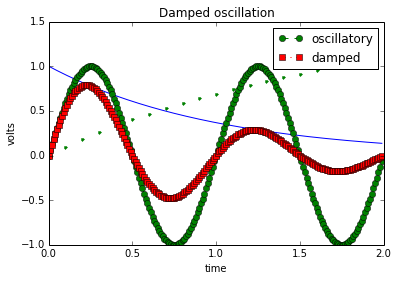

```python
# Set new mpl figure object
mpl_fig2 = plt.figure()

# Replot first mpl figure, add legend
(l1, l2, l3, l4) = plot_mpl_fig()
plt.legend((l2, l4), ('oscillatory', 'damped'), 'upper right')
```

```python
# Plot mpl figure object as a Plotly plot
py.iplot_mpl(mpl_fig2, filename='s6_damped_oscillation-legend')
```

[interactive chart not shown]

Legends are treated as simple text annotations.

That said, once you have the Plotly figure in hand, it is pretty straight forward to add a Plotly legend to your Plotly plot:

```python
# Convert mpl fig obj to plotly fig obj, resize to plotly's default
py_fig2 = tls.mpl_to_plotly(mpl_fig2, resize=True)

# Delete misplaced legend annotations
py_fig2['layout'].pop('annotations', None)

# Add legend, place it at the top right corner of the plot
py_fig2['layout'].update(
    showlegend=True,
    legend=Legend(
        x=1.05,
        y=1
    )
)

# Send updated figure object to Plotly, show result in notebook
py.iplot(py_fig2, filename='s6_damped_oscillation-legend2')
```

[interactive chart not shown]

Again, Plotly caught the `label` keyword from the `plt.line` call.

To make it look like the original matplotlib plot, we need to add a few key-value pairs to the trace objects:

```python
# Add name to be shown on hover and legend for two of the traces
py_fig2['data'][1].update(name='oscillatory')
py_fig2['data'][3].update(name='damped')

# Do not include the remaining traces in legend
py_fig2['data'][0].update(showlegend=False)
py_fig2['data'][2].update(showlegend=False)

# Send updated figure object to Plotly, show result in notebook
py.iplot(py_fig2, filename='s6_damped_oscillation-legend3')
```

[interactive chart not shown]

This is much better than the orginal matplotlib figure, right?

The previous updates can be made by passing a single keyword argument to `py.iplot_mpl` :

```python
# Update dictionary
update = dict(
    layout=dict(
        annotations=[dict(text=' ')],  # blank text in legend 'annotation'
        showlegend=True,               # show legend
        legend=Legend(
            x=1.05,     # legend position
            y=1
        )
    ),
    data=[
        dict(showlegend=False),   # do not show trace 1 in legend
        dict(name='oscillatory'), # legend label for trace 2
        dict(showlegend=False),   # do not show trace 3 in legend
        dict(name='damped')       # legend label for trace 4
    ]
)

# Plot mpl figure object as a Plotly plot, with update dictionary
py.iplot_mpl(mpl_fig2, resize=True, update=update,
             filename='s6_damped_oscillation-legend4')
```

[interactive chart not shown]

Thank you [Adam Hughes](https://twitter.com/hughesadam87) for the suggestion.

### 6.2 Supported plot types

So far, matplotlylib supports convertions of:

- Scatter Plots (i.e. marker and line plots), as shown in subsection 6.1
- Bar Charts
- Histograms
- Log scales
- Bubble Charts

Here are a couple examples:

##### Bar Charts

```
<Container object of 7 artists>
```

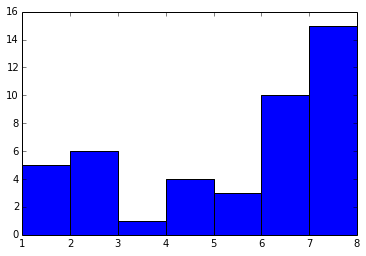

```python
mpl_fig_bar = plt.figure()  # set new mpl figure object

ax = mpl_fig_bar.add_subplot(111)  # add axis

# Locations and height of the bars
locs = [1, 2, 3, 4, 5, 6, 7]
height = [5, 6, 1, 4, 3, 10, 15]

# Plot mpl bar chart, bars have a width of 1 unit
ax.bar(locs, height, width=1)
```

```python
# Convert mpl figure object to Plotly plot
py.iplot_mpl(mpl_fig_bar, filename='s6_bars')
```

[interactive chart not shown]

Recall that, by default, `py.plot_mpl` and `py.iplot_mpl` resize the inputted matplotlib figure object.

##### Histograms

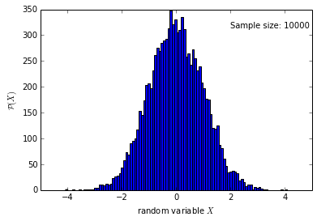

```python
mpl_fig_hist = plt.figure()  # set new mpl figure objects

ax = mpl_fig_hist.add_subplot(111)  # add axis

N = 10000  # sample size

y = np.random.randn(N)  # normally distribution random numbers

ax.set_xlabel(r"random variable $X$")  # set axis labels
ax.set_ylabel(r"$\mathcal{P}(X)$")     #  using LaTeX symbols

# Add an on-plot annotation
ax.annotate('Sample size: ' + str(N),
            textcoords='axes fraction',
            xy=(0.7,0.9), xytext=(0.7,0.9))

# Plot mpl histogram with 100 bins
out = ax.hist(y, bins=100)
```

```python
# Convert mpl figure object to Plotly plot
py.iplot_mpl(mpl_fig_hist, filename='s6_histograms')
```

[interactive chart not shown]

Nice!

Matplotlylib is able to convert $\LaTeX$ symbols from matplotlib figure objects as well as text annotations with ease.

Please note that matplotlylib converts matplotlib histograms into Plotly `Bar` objects (not into Plotly `Histogram` objects). More clearly,

```python
# Convert mpl figure object to plotly
py_fig_hist = tls.mpl_to_plotly(mpl_fig_hist)

# Print the yielded plotly figure object
print(py_fig_hist.to_string())
```

```
Figure(
    data=Data([
        Bar(
            x=[-4.0300728711721483, -3.9484305111402387, -3.8667881511083.., ],
            y=[1.0, 0.0, 0.0, 1.0, 0.0, 0.0, 2.0, 0.0, 2.0, 1.0, 1.0, 2.0,   ],
            orientation='v',
            marker=Marker(
                color='#0000FF',
                line=Line(
                    width=1.0
                )
            ),
            opacity=1,
            xaxis='x1',
            yaxis='y1'
        )
    ]),
    layout=Layout(
        showlegend=False,
        autosize=False,
        width=480,
        height=320,
        annotations=Annotations([
            Annotation(
                x=0.6981233243967828,
                y=0.8963855421686748,
                xref='paper',
                yref='paper',
                text='Sample size: 10000',
                showarrow=False,
                font=Font(
                    size=10.0,
                    color='#000000'
                ),
                xanchor='left',
                yanchor='bottom',
                align='left',
                opacity=1
            )
        ]),
```

[output cut: 38 more lines]

```
            type='linear',
            showgrid=False,
            zeroline=False,
            showline=True,
            nticks=8,
            ticks='inside',
            tickfont=Font(
                size=10.0
            ),
            mirror='ticks',
            anchor='x1',
            side='left'
        )
    )
)
```

That is, the computation required to plot a histogram from a set of values is not made twice.

##### Log scales

The following plot was inspired by the [log demo](http://matplotlib.org/examples/pylab_examples/log_demo.html) of the matplotlib example bank.

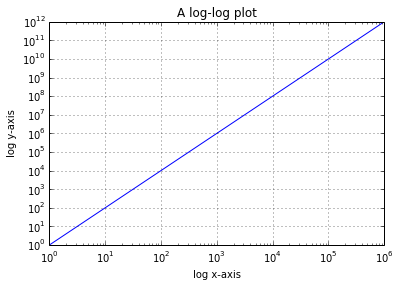

```python
mpl_fig_log = plt.figure()  # set new mpl figure object

ax = mpl_fig_log.add_subplot(111)  # add axis

# A simple exponential y=x^2
x = 10.0**np.linspace(0.0, 6.0, 20)
y = x**2.0

plt.loglog(x,y) # plot as log-log

# Add title, axis labels and grid
plt.title('A log-log plot')
ax.set_xlabel('log x-axis')
ax.set_ylabel('log y-axis')
plt.grid(True)
```

```python
# Convert mpl figure object to Plotly plot
py.iplot_mpl(mpl_fig_log, filename='s6_log-scales')
```

[interactive chart not shown]

The tick labels on the Plotly figure are not exactly the same as on the matplotlib figure. Hopefully, you agree that the converted tick labels look better than the original.

##### Bubble Charts

The following example was inspired by this [post](http://glowingpython.blogspot.ca/2011/11/how-to-make-bubble-charts-with.html) on the Glowing Python blog. Thanks!

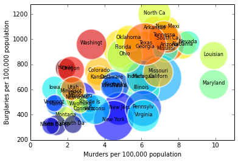

```python
import urllib2       # (*) urllib2 for in-session downloads
import pandas as pd  # (*) pandas for dataframe manipulation

# Import data file from URL into pd datafram in session
data_url = 'http://datasets.flowingdata.com/crimeRatesByState2005.csv'
data_file = urllib2.urlopen(data_url)
df = pd.read_csv(data_file, sep=',')

df = df.drop(df.index[0])  # drop first row (US totals)
df = df[df['murder'] < 11] # drop out-of-range rows

mpl_fig_bubble = plt.figure()         # (!) set new mpl figure object
ax = mpl_fig_bubble.add_subplot(111)  # add axis

plt.axis([0,11,200,1280])
plt.xlabel('Murders per 100,000 population')
plt.ylabel('Burglaries per 100,000 population')

scatter = ax.scatter(
    df['murder'],
    df['burglary'],
    c=df['larceny_theft'],        # using some color scale
    s=np.sqrt(df['population']),
    linewidths=2,
    edgecolor='w',
    alpha=0.6
)

for i_X, X in df.iterrows():
    plt.text(
        X['murder'],
        X['burglary'],
        X['state'][0:8], # only the first 8 letters
        size=8,
        horizontalalignment='center'
    )
```

```python
# Convert mpl figure object to Plotly plot
py.iplot_mpl(mpl_fig_bubble, filename='s6_bubble-chart')
```

[interactive chart not shown]

For another matplotlylib examples, refer to our online [documentation](https://plot.ly/matplotlib/) .